# Clustering UFC Fighters: K-means and Hierarchical

Jason Willett

@@ Read in all the data sets

```r
ufc = read.csv("ufcdataupdated.csv") # complete dataset of all fights
ufcfighters = read.csv("ufcfighters.csv") # physical characteristics of all fighters
bigufc = read.csv("bigufc.csv") # unpolished dataset of fights
```

## Of the 2697 fights:

## Red won 56% of the fights.

## Blue won 42% of the fights.

## Draw occurred in 2% of the fights.

## Create a binary win column

```r
Binwin = c(rep(0, length(ufc$Winner)))
for (i in 1:length(ufc$Winner)) {
  if (ufc$Winner[i] == "Red"){
    Binwin[i] = 1
  }

}
ufc = data.frame(cbind(ufc,Binwin))
```

## Now I have added an entire column that indicates whether or not Red fighter won. It is binary. ## 1 means won and 0 means loss/draw.

# Create a dataframe of all the fighters featured within the fights

```r
rlevs = c(levels(factor(ufc$R_fighter))) # find unique red fighters
blevs = c(levels(factor(ufc$B_fighter))) # find unique blue fighters
combinedlevs = c(rlevs,blevs)
levsframe = data.frame(c(rep(0,length(combinedlevs))))
for (i in 1:length(combinedlevs)) {
  levsframe[i,1] = combinedlevs[i]

}
```

## Factor all the rows of levsframe to find more levels

```r
levsframe[,1] = factor(levsframe[,1])
```

## Find unique fighters for combined rlevs and blevs frame

```r
finnamelevs = data.frame(c(levels(levsframe[,1])))
```

## Change type of element from factor to character

```r
finnamelevs[,1] = as.character(finnamelevs[,1])
```

## Load in tidyr package

```r
library(tidyr)
```

## Remove unnecessary columns from ufc dataset: rowidx, referee name, location, Winner (created ## binary column)

```r
ufc = subset(ufc, select = -c(X, Unnamed..0,Referee,location,Winner))
```

# Keep only columns relating to red fighters

```r
library(dplyr)
R_col = ufc %>% select(contains("date"),,contains("weight_class"),contains("R_"))
```

## Keep only columns relating to blue fighters

```r
B_col = ufc %>% select(contains("date"),contains("weight_class"),contains("B_"))
```

## Remove “R_” and “B_” from column names to standardize

```r
names(R_col) = gsub("R_","",names(R_col))
names(B_col) = gsub("B_","",names(B_col))
```

## Remove any remaining columns that should not be in the dataset

```r
R_col = subset(R_col, select = -c(B_avg_SIG_STatt,B_avg_SIG_STlanded,B_avg_SIG_STpct,B_avg_TOTAL_STatt,B_avg_TOTAL_STlanded,B_avg_opp_SIG_STatt,B_avg_opp_SIG_STlanded,B_avg_opp_SIG_STpct,B_avg_opp_TOTAL_STatt,B_avg_opp_TOTAL_STlanded, B_win_by_TKO_Doctor_Stoppage,age))
B_col = subset(B_col, select = -c(R_avg_SUATT,R_avg_opp_SUATT, age))
```

## Remove any antecedents to standardize

```r
names(R_col) = gsub("B_","",names(R_col))
names(B_col) = gsub("R_","",names(B_col))
R_col[1,]
```

```
##         date weight_class      fighter current_lose_streak current_win_streak
## 1 2019-06-08 Bantamweight Henry Cejudo                   0                  4
##   draw avg_BODY_att avg_BODY_landed avg_CLINCH_att avg_CLINCH_landed
## 1    0         21.9            16.4             17                11
##   avg_DISTANCE_att avg_DISTANCE_landed avg_GROUND_att avg_GROUND_landed
## 1               75                26.5            9.4               6.5
##   avg_HEAD_att avg_HEAD_landed avg_KD avg_LEG_att avg_LEG_landed avg_PASS
## 1         74.2            23.9    0.4         5.3            3.7      1.2
##   avg_REV avg_SIG_STatt avg_SIG_STlanded avg_SIG_STpct avg_SUATT avg_TD_att
## 1       0         101.4               44         0.466       0.1        5.3
##   avg_TD_landed avg_TD_pct avg_TOTAL_STatt avg_TOTAL_STlanded
## 1           1.9      0.458           129.9               69.1
##   longest_win_streak losses avg_opp_BODY_att avg_opp_BODY_landed
## 1                  4      2             13.3                 8.8
##   avg_opp_CLINCH_att avg_opp_CLINCH_landed avg_opp_DISTANCE_att
## 1                7.5                   5.1                 90.5
##   avg_opp_DISTANCE_landed avg_opp_GROUND_att avg_opp_GROUND_landed
## 1                    26.8                0.8                   0.3
##   avg_opp_HEAD_att avg_opp_HEAD_landed avg_opp_KD avg_opp_LEG_att
## 1             76.1                17.3        0.1             9.4
##   avg_opp_LEG_landed avg_opp_PASS avg_opp_REV avg_opp_SIG_STatt
## 1                6.1            0           0              98.8
##   avg_opp_SIG_STlanded avg_opp_SIG_STpct avg_opp_SUATT avg_opp_TD_att
## 1                 32.2             0.336             0            0.9
##   avg_opp_TD_landed avg_opp_TD_pct avg_opp_TOTAL_STatt avg_opp_TOTAL_STlanded
## 1               0.1           0.05               110.5                   43.3
##   total_rounds_fought total_time_fought.seconds. total_title_bouts
## 1                  27                      742.6                 3
##   win_by_Decision_Majority win_by_Decision_Split win_by_Decision_Unanimous
## 1                        0                     2                         4
##   win_by_KO.TKO win_by_Submission win_by_TKO_Doctor_Stoppage wins   Stance
## 1             2                 0                          0    8 Orthodox
##   Height_cms Reach_cms Weight_lbs odds
## 1     162.56    162.56        135  145
```

## Combine red and blue revised subsetted data into one dataset

```r
ufc = rbind(R_col,B_col)
```

## Find most recent fight for each fighter

```r
ufc = ufc[order(ufc$date),] #prder the fights by date
recfight = ufc[which(ufc$fighter == finnamelevs[1,]),]
```

## Find most recent for each fighter and append to recfight dataframe

```r
for (i in 2:length(finnamelevs[,1])) {
  maxx = max(which(ufc$fighter == finnamelevs[i,]))
  fight = ufc[maxx,]
  recfight = rbind(recfight,fight)

}
recfight = data.frame(recfight) # make dataframe
```

## Make rownames the fighters name for making it clear in clustering later on

```r
rownames(recfight) = recfight$fighter
```

## Remove any remaining columns that will not be necessary for clustering or clumns that are not ## of interest

```r
fighter_features = subset(recfight, select = -c(losses,odds, Stance, wins,total_rounds_fought,total_time_fought.seconds.,total_title_bouts,win_by_Decision_Majority,win_by_Decision_Split,win_by_Decision_Unanimous,win_by_KO.TKO,win_by_Submission,win_by_TKO_Doctor_Stoppage,date,fighter,current_lose_streak,current_win_streak,draw,weight_class,longest_win_streak))
```

## Scale and standaridize all columns to make sure no feature is given more power because its on a larger scale

```r
m = apply(fighter_features,2,mean)
s = apply(fighter_features,2,sd)
fighter_features = scale(fighter_features,m,s) # z-score standardization
```

## Find sum of WCC for each number of clusters allowed to perform elbow method

```r
set.seed(1234)
kmean2 = kmeans(fighter_features,2)
mWCC_list = mean(kmean2$withinss)
for (i in 2:10) {
  kmea = kmeans(fighter_features, i)
  mWCC = mean(kmea$withinss)
  mWCC_list = c(mWCC_list,mWCC)
}
mWCC_list
```

```
##  [1] 22561.886 22561.886 14132.605  9782.639  7462.857  6038.049  4980.895
##  [8]  4241.884  3660.383  3246.296
```

## Create plot of sWCC to perform elbow method

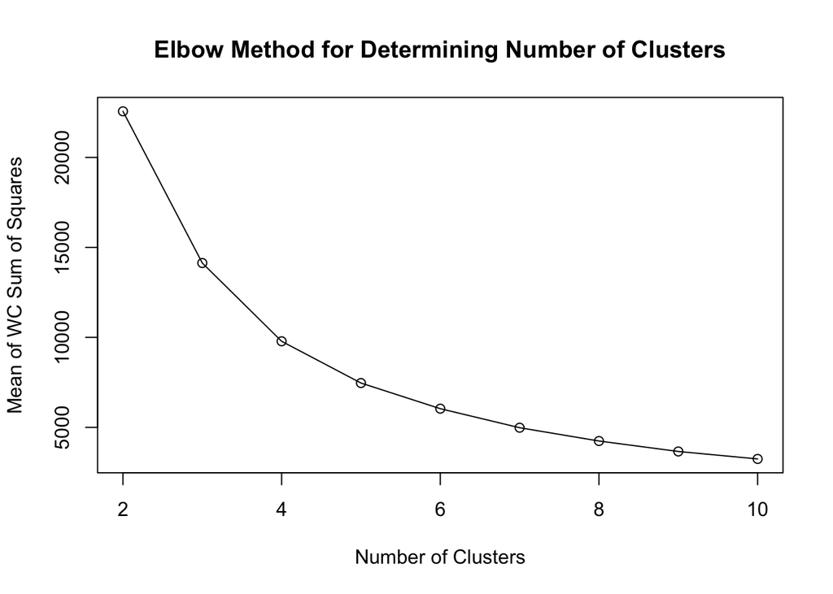

```r
cluster_size = c(2:10)
plot(cluster_size,mWCC_list[2:10], main = "Elbow Method for Determining Number of Clusters", xlab = "Number of Clusters", ylab = "Mean of WC Sum of Squares", type = "o")
```

## Based off elbow method, looks like 3 or 4 clusters is the optimal number of clusters

## Find silhouette coefficent: alternate method for finding optimal number of clusters

```r
library(cluster)
set.seed(2020)
asw <- numeric(20)
for (k in 2:20){
  asw[k] <- pam(fighter_features, k) $ silinfo $ avg.width
  k.best <- which.max(asw)
}
cat("silhouette-optimal number of clusters:", k.best, "\n")
```

```
## silhouette-optimal number of clusters: 2
```

## According to the elbow method, it appears we should set k=3. However, based off

## SilhouetteCoefficients, we should set k=2.

## Use k-means with 2 clusters and 3 clusters

```r
set.seed(2020)
results2 = kmeans(fighter_features, 2)
results3 = kmeans(fighter_features, 3)
```

## Explore the k-means with 3 clusters

```r
table(recfight$weight_class,results3$cluster) # table comparing cluster assignment to weight class
```

```
##
##                           1   2   3
##   Bantamweight           52  15  49
##   Catch Weight            2   0   0
##   Featherweight          48  16  57
##   Flyweight              15  20  25
##   Heavyweight            14   5  63
##   Light Heavyweight      12  13  73
##   Lightweight            64  28 100
##   Middleweight           29  13  93
##   Welterweight           60  25 119
##   Women's Bantamweight   12   8   4
##   Women's Featherweight   2   1   2
##   Women's Flyweight      16   5   4
##   Women's Strawweight    27   4   4
```

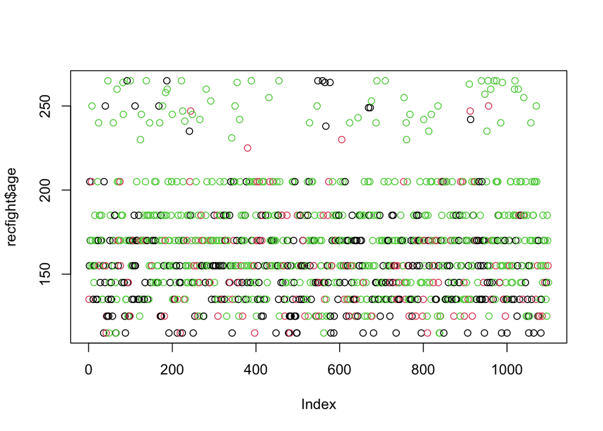

```r
plot(recfight$Weight_lbs,recfight$age,col=results3$cluster) # age vs cluster
```

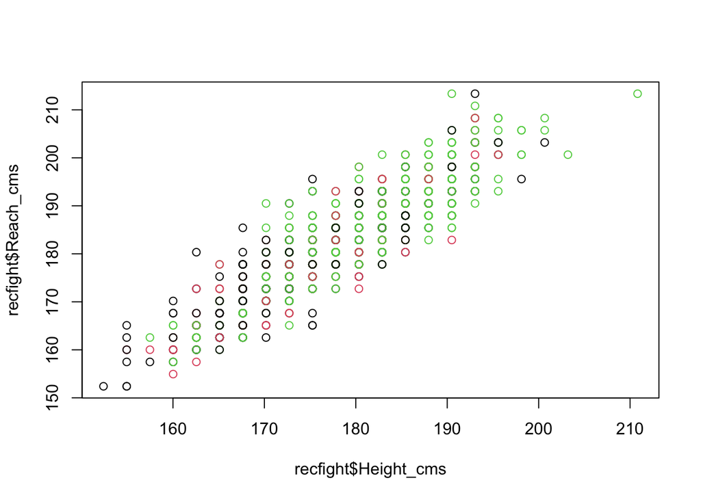

```r
plot(recfight$Height_cms,recfight$Reach_cms,col=results3$cluster) # arm length
```

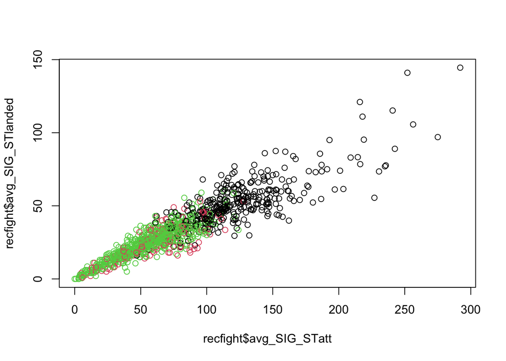

```r
# plots below are some fighting statistic comparisons
plot(recfight$avg_SIG_STatt,recfight$avg_SIG_STlanded,col=results3$cluster)
```

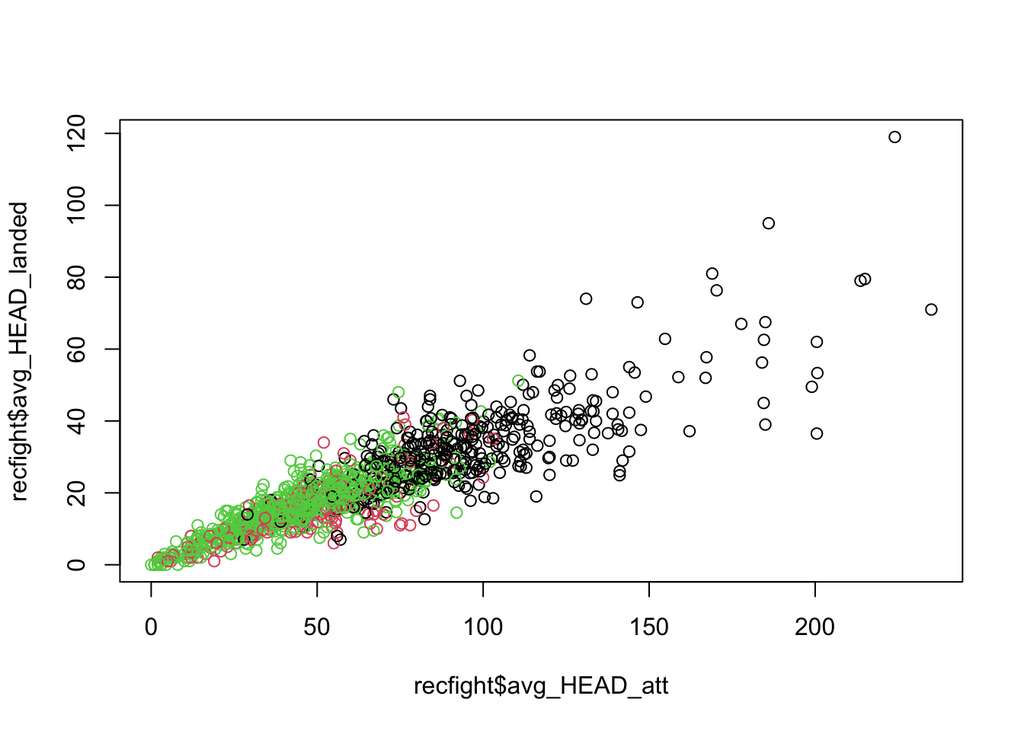

```r
plot(recfight$avg_HEAD_att,recfight$avg_HEAD_landed,col=results3$cluster)
```

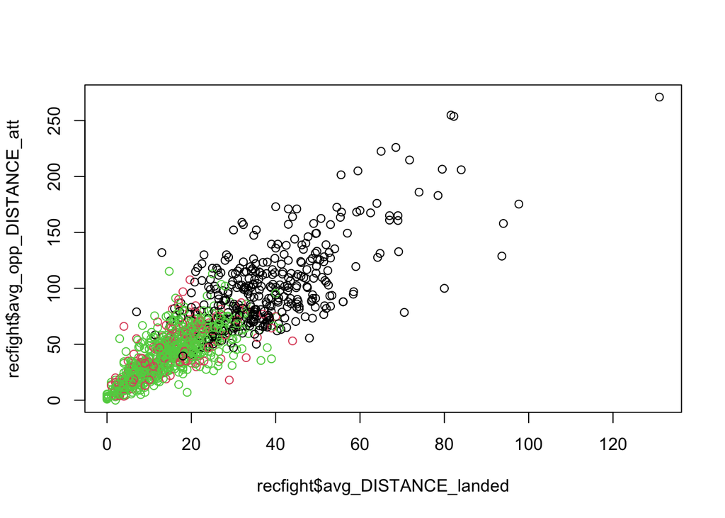

```r
plot(recfight$avg_DISTANCE_landed,recfight$avg_opp_DISTANCE_att,col=results3$cluster)
```

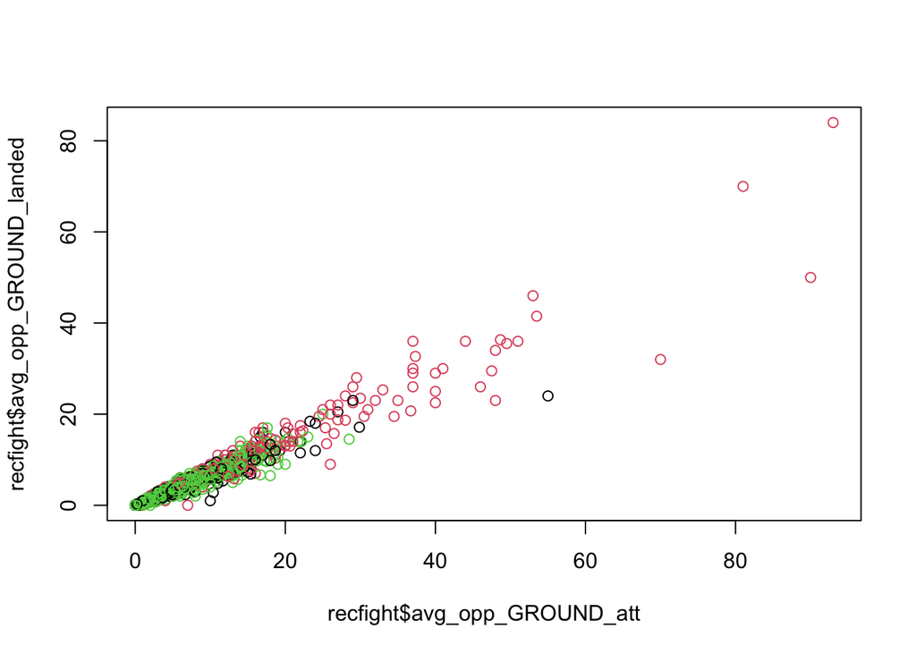

```r
plot(recfight$avg_opp_GROUND_att,recfight$avg_opp_GROUND_landed,col=results3$cluster)
```

## Create standardized plots for fighter stats and opponent stats

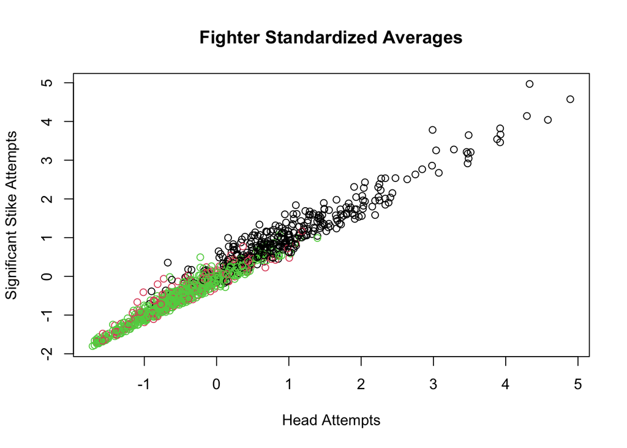

```r
mha = mean(recfight$avg_HEAD_att)
sha = sd(recfight$avg_HEAD_att)
avg_head_att = scale(recfight$avg_HEAD_att,mha,sha)
mhl = mean(recfight$avg_HEAD_landed)
shl = sd(recfight$avg_HEAD_landed)
avg_head_land = scale(recfight$avg_HEAD_landed,mhl,shl)
mssa = mean(recfight$avg_SIG_STatt)
sssa = sd(recfight$avg_SIG_STatt)
avg_SS_att = scale(recfight$avg_SIG_STatt,mssa,sssa)
moha = mean(recfight$avg_opp_HEAD_att)
soha = sd(recfight$avg_opp_HEAD_att)
avg_opp_head = scale(recfight$avg_opp_HEAD_att,moha,soha)
moda = mean(recfight$avg_opp_DISTANCE_att)
soda = sd(recfight$avg_opp_DISTANCE_att)
avg_opp_dist = scale(recfight$avg_opp_DISTANCE_att,moda,soda)
plot(avg_head_att,avg_SS_att,main = "Fighter Standardized Averages", xlab = "Head Attempts", ylab = "Significant Stike Attempts", col = results3$cluster)
```

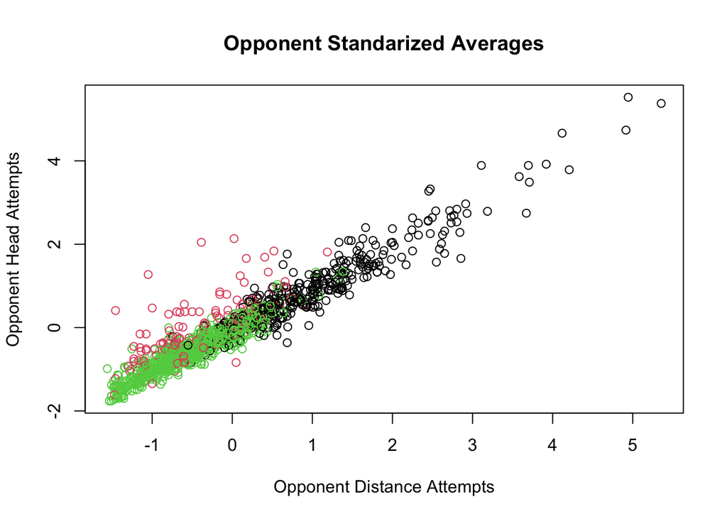

```r
plot(avg_opp_dist,avg_opp_head, main = "Opponent Standarized Averages",xlab = "Opponent Distance Attempts",ylab = "Opponent Head Attempts",col = results3$cluster)
```

## Find win probability for each cluster

```r
cluster1wper = sum(recfight$wins[which(results3$cluster == 1)]) / (sum(recfight$wins[which(results3$cluster == 1)]) + (sum(recfight$losses[which(results3$cluster == 1)])) + (sum(recfight$draw[which(results3$cluster == 1)])))
cluster2wper = sum(recfight$wins[which(results3$cluster == 2)]) / (sum(recfight$wins[which(results3$cluster == 2)]) + (sum(recfight$losses[which(results3$cluster == 2)])) + (sum(recfight$draw[which(results3$cluster == 2)])))
cluster3wper = sum(recfight$wins[which(results3$cluster == 3)]) / (sum(recfight$wins[which(results3$cluster == 3)]) + (sum(recfight$losses[which(results3$cluster == 3)])) + (sum(recfight$draw[which(results3$cluster == 3)])))
winp = c(cluster1wper,cluster2wper,cluster3wper)
winp
```

```
## [1] 0.6056161 0.3894140 0.5845824
```

## Hierarchal Clustering

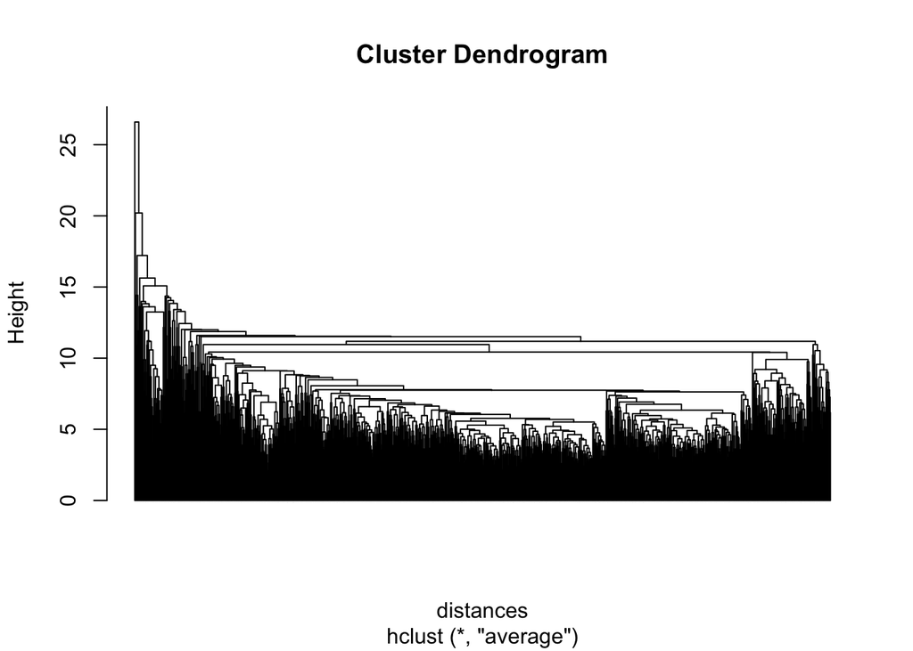

```r
set.seed(2020)
distances = dist(fighter_features)
hclustermod2 = hclust(distances, method = "average")
plot(hclustermod2, hang = -4, cex=.01)
```

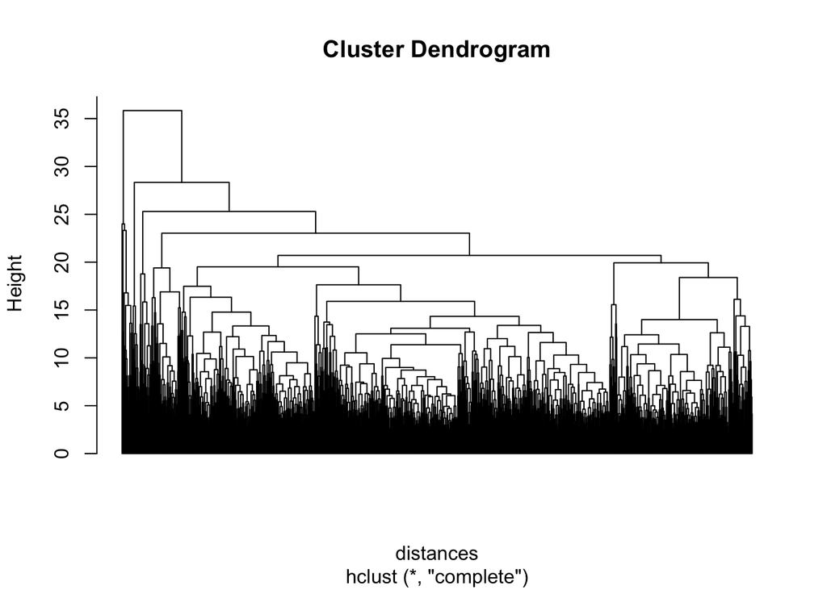

```r
hclustermod = hclust(distances)
plot(hclustermod, hang = -4, cex=.01)
```

```r
set.seed(2020)
clusterCut1 = cutree(hclustermod, 3)
table(recfight$weight_class,clusterCut1)
```

```
##                        clusterCut1
##                           1   2   3
##   Bantamweight          112   4   0
##   Catch Weight            2   0   0
##   Featherweight         116   3   2
##   Flyweight              57   0   3
##   Heavyweight            80   2   0
##   Light Heavyweight      97   0   1
##   Lightweight           186   2   4
##   Middleweight          133   1   1
##   Welterweight          203   1   0
##   Women's Bantamweight   21   3   0
##   Women's Featherweight   5   0   0
##   Women's Flyweight      22   2   1
##   Women's Strawweight    34   1   0
```

```r
#set.seed(2020)
#clusterCut2 = cutree(hclustermod2, 3)
#table(recfight$weight_class,clusterCut2)
```

Average Hierarchal did not do well.

## Understanding clusters from k-meabs with 3 clusters (Optimal Clusters)

```r
results3
```

```
## K-means clustering with 3 clusters of sizes 353, 153, 593
##
## Cluster means:
##   avg_BODY_att avg_BODY_landed avg_CLINCH_att avg_CLINCH_landed
## 1    0.8525111       0.7989322      0.5274248        0.50108068
## 2   -0.1305423      -0.1277639     -0.0472439       -0.05120781
## 3   -0.4738001      -0.4426226     -0.3017751       -0.28507030
##   avg_DISTANCE_att avg_DISTANCE_landed avg_GROUND_att avg_GROUND_landed
## 1        1.0415191           1.0424666     0.03639388        0.04846871
## 2       -0.3542822          -0.4153387    -0.26998026       -0.27343203
## 3       -0.5285853          -0.5133961     0.04799315        0.04169586
##   avg_HEAD_att avg_HEAD_landed      avg_KD avg_LEG_att avg_LEG_landed
## 1    1.0110659       0.9147010  0.03347434   0.6889606      0.7149359
## 2   -0.3988996      -0.4684377 -0.43872786  -0.2644190     -0.3182088
## 3   -0.4989454      -0.4236399  0.09326968  -0.3419005     -0.3434847
##      avg_PASS     avg_REV avg_SIG_STatt avg_SIG_STlanded avg_SIG_STpct
## 1 -0.07863901 -0.13135481     1.0650955        1.0297109   -0.08066013
## 2 -0.18143371  0.64415825    -0.3864504       -0.4424298   -0.20832433
## 3  0.09362382 -0.08800668    -0.5343201       -0.4988131    0.10176501
##     avg_SUATT  avg_TD_att avg_TD_landed  avg_TD_pct avg_TOTAL_STatt
## 1 -0.21079590  0.14283035    0.07164922  0.01195757       0.9945982
## 2  0.26889527 -0.30643655   -0.34028538 -0.40426105      -0.2869450
## 3  0.05610451 -0.00596007    0.04514585  0.09718536      -0.5180279
##   avg_TOTAL_STlanded avg_opp_BODY_att avg_opp_BODY_landed avg_opp_CLINCH_att
## 1          0.7877110       0.83101564           0.7060958          0.4167538
## 2         -0.2155285       0.04410483           0.2125331          0.1887432
## 3         -0.4132987      -0.50606503          -0.4751591         -0.2967821
##   avg_opp_CLINCH_landed avg_opp_DISTANCE_att avg_opp_DISTANCE_landed
## 1             0.3578014            1.0386660               0.9900042
## 2             0.2398354           -0.3753214              -0.2621207
## 3            -0.2748713           -0.5214585              -0.5216982
##   avg_opp_GROUND_att avg_opp_GROUND_landed avg_opp_HEAD_att avg_opp_HEAD_landed
## 1         -0.2290571            -0.2387454       0.96482456           0.7205944
## 2          1.3222649             1.3516479      -0.03237643           0.4445513
## 3         -0.2048050            -0.2066189      -0.56598562          -0.5436529
##   avg_opp_KD avg_opp_LEG_att avg_opp_LEG_landed avg_opp_PASS avg_opp_REV
## 1 -0.1419043      0.66497668         0.65601355   -0.2190264 -0.12214180
## 2 -0.2371142     -0.07375366        -0.02439301    1.4619850  0.49376573
## 3  0.1456504     -0.37681696        -0.38421695   -0.2468253 -0.05468819
##   avg_opp_SIG_STatt avg_opp_SIG_STlanded avg_opp_SIG_STpct avg_opp_SUATT
```

[output cut: 741 more lines]

```
##              Yves Jabouin     Zabit Magomedsharipov             Zach Makovsky
##                         3                         1                         3
##              Zak Cummings                 Zak Ottow              Zhang Lipeng
##                         3                         3                         2
##          Zubaira Tukhugov
##                         3
##
## Within cluster sum of squares by cluster:
## [1] 16665.523  8696.688 17036.202
##  (between_SS / total_SS =  24.3 %)
##
## Available components:
##
## [1] "cluster"      "centers"      "totss"        "withinss"     "tot.withinss"
## [6] "betweenss"    "size"         "iter"         "ifault"
```